# My Two-way ANOVA: Study Hours

W06 Analysis

Andrew Seaman

March 3rd, 2026

```r
library(mosaic)
library(DT)
library(pander)
library(car)
library(ggplot2)
library(tidyverse)
library(lubridate)
library(lattice) # ChatGPT recommended using this library to help creat the graphics.
```

```r
# ————————————————————————————————————————————————————————————————————————
# Record your data from your own mini experiment in Excel.
# Save the data as a .csv file in the Data folder of the Statistics-Notebook.
# ————————————————————————————————————————————————————————————————————————

# Read in the data
source <- read.csv("../../Data/StudyHours/StudyHours_with_zeros.csv")

# Data columns: actual data used for the analysis.
# Cleaning: Rename (if needed) and assign correct data types.
StudyHours <- source %>%
  rename(Weekday = Day) %>%
  mutate(
    Date = dmy(Date),                                # Convert to Date type
    Weekday = factor(Weekday,
                     levels = c("Monday", "Tuesday", "Wednesday",
                                "Thursday", "Friday", "Saturday", "Sunday")),
    Week = as.integer(Week),
    Course_Code = as.character(Course_Code),
    Credits_Hours = as.integer(Credits_Hours),
    RecHr_Weekly = as.integer(RecHr_Weekly),
    RecHr_Daily = as.numeric(RecHr_Daily),           # Numeric (float)
    Hours = as.numeric(Hours),
    Met_RecHr_Weekly = as.logical(Met_RecHr_Weekly), # Convert to TRUE/FALSE
    Sick = as.logical(Sick)                          # Convert to TRUE/FALSE
  ) %>%
  filter(!is.na(Hours)) %>%                          # remove rows with NA in Hours
  select(-Notes, -Hex_Code, -Course_Name)

# Reference columns:
Color_Guide <- source %>%
  select(Course_Code, Hex_Code) %>%
  slice_head(n = 5)
```

## Background

### Show

During the Winter Semester of 2024 (Jan 8th - Apr 10th) Andrew Seaman (*the Student*), a student at Brigham Young University — Idaho, recorded his study hours (not including in-class study time). Through rigorous employment of a personal calendar the Student tracked their study hours per day and per course. The Student’s **course load** included:

```r
# Course Load Table: pull out the needed columns and add a "Total" row.

course_load <- source %>%
  slice_head(n = 5) %>%
  transmute(
    Code = Course_Code,
    Name = Course_Name,
    `Credit Hours` = Credits_Hours,
    `Rec. Weekly Study Hours` = RecHr_Weekly
  ) %>%
  { df <- .;
    add_row(
      df,
      Code = "Total",
      Name = as.character(nrow(df)),            # course count
      `Credit Hours` = sum(df$`Credit Hours`, na.rm = TRUE),
      `Rec. Weekly Study Hours` = sum(df$`Rec. Weekly Study Hours`, na.rm = TRUE)
    )
  }

pander(course_load, justify = c("left", "left", "center", "center"))
```

| Code | Name | Credit Hours | Rec. Weekly Study Hours |
| --- | --- | --- | --- |
| ACCTG 201 | Financial Accounting | 3 | 9 |
| MATH 101 | Intermediate Algebra | 4 | 12 |
| CSE 111 | Programming with Functions | 2 | 6 |
| MKT 275 | Professional Selling | 3 | 9 |
| MATH 221D | Intro Statistics with R | 3 | 9 |
| Total | 5 | 15 | 45 |

*(Note: it is recommended by the University to estimate weekly study hours for a course equal to “credit hours * (times) 3”.)*

The Student shared they began this project out of personal necessity to make his time management skill development visible so he could better approach learning how he used his time, when, and where. He added it was deeply insightful to glimpse even basic statistics as a result of his “personal study” however he is now interested in determining which factors may have had significant impact on the distribution of his time spent studying.

### Hide

*Click the tabs to see more detail.*

## Analysis

### Hypotheses

The data was recorded for each course per day per week meaning the day of the week (`Weekday`) as well as the course (`Course`) are interesting factors which may have had significant impact on the distribution of study hours. Due to this multi-factored interaction it is most appropriate to use a two-way ANOVA test to evaluate the influence of each factor separately as well as their interaction.

$$\text{A significance level of} \ \alpha = 0.05 \ \text{will be used for
this study.}$$

> Set 1: **Weekday** (One-way ANOVA)

Hypotheses about the impact `Weekday` has on $\mu$ which represents the mean number of hours studied outside of class time. Does the pattern of mean study hours across the days change or are they all equal?
$$H_0:\ \mu_{\text{Mon}}=\mu_{\text{Tue}}=\cdots=\mu_{\text{Sun}}
\\
H_a:\ \text{not all } \mu_k \text{ are equal}$$

> Set 2: **Course:** (One-way ANOVA)

Hypotheses about the impact `Course` has on $\mu$ which represents the mean number of hours studied outside of class time by course. Does the pattern of mean study hours across the courses change or are they all equal?

$$H_0:\
\mu_{\text{ACCTG201}}=\mu_{\text{MATH101}}=\mu_{\text{CSE111}}=\mu_{\text{MKT275}}=\mu_{\text{MATH221D}}
\\
H_a:\ \text{not all } \mu_k \text{ are equal}$$

> Set 3: **Weekday:Course** (Two-way ANOVA)

Hypotheses about the interaction of Weekday and Course. Does the pattern of mean study hours across the days of the week change depending on which course it is? Or does the pattern show low mean study hours for all courses on a specific day? Or does a certain course have consistently lower mean study hours each day of the week?
$$H_0: \text{The effect of Weekday on Hours is the same for all levels of
Course}
\\
H_a: \text{The effect of Weekday on Hours is not the same for all levels
of Course}$$

### Two-way ANOVA Test

We will analyze the hypothesized significance of the two factors by computing the following Two-way ANOVA test.

```r
# Two-way ANOVA:

hours_aov <- aov(Hours ~ Weekday + Course_Code + Weekday:Course_Code, data = StudyHours)

results_aov <- summary(hours_aov)

# Raw output:
# results_aov

# Clean output:
pander(results_aov,
       justify = c("left", "center", "center", "center", "center", "center"))
```

Analysis of Variance Model

|  | Df | Sum Sq | Mean Sq | F value | Pr(>F) |
| --- | --- | --- | --- | --- | --- |
| **Weekday** | 6 | 92.02 | 15.34 | 3.769 | 0.001142 |
| **Course_Code** | 4 | 78.14 | 19.53 | 4.8 | 0.0008493 |
| **Weekday:Course_Code** | 24 | 186.9 | 7.789 | 1.914 | 0.006241 |
| **Residuals** | 432 | 1758 | 4.07 | NA | NA |

For interpretation we first ask,“*Which p-values were significant?*” In this case we have three tests. Each factor was run through a one-way ANOVA test and then jointly the pair of factors were used in the two-way ANOVA test. All three tests are showing significance (p-value < $\alpha$ = 0.05):

- **Weekday:** p-value = 0.001142
- **Course_Code (or Course):** p-value = 0.0008493
- **Weekday:Course:** p-value = 0.006241

#### Diagnostic Plots

*(Disclosure - Source: ChatGPT (sharpening Author’s explanation))*

In evaluating the appropriateness of an ANOVA, two main assumptions must be met:

1. The residuals should be normally distributed.
2. The variance of residuals should be constant across all levels of the factors (homoscedasticity).

The Q-Q plot shows substantial deviation from the diagonal, especially in the tails, indicating non-normal residuals. The Residuals vs Fitted plot displays a curved, “fan-shaped” pattern rather than random scatter, indicating heteroscedasticity. These violations suggest that the ANOVA results should be **interpreted with caution**, as the model assumptions are not well met.

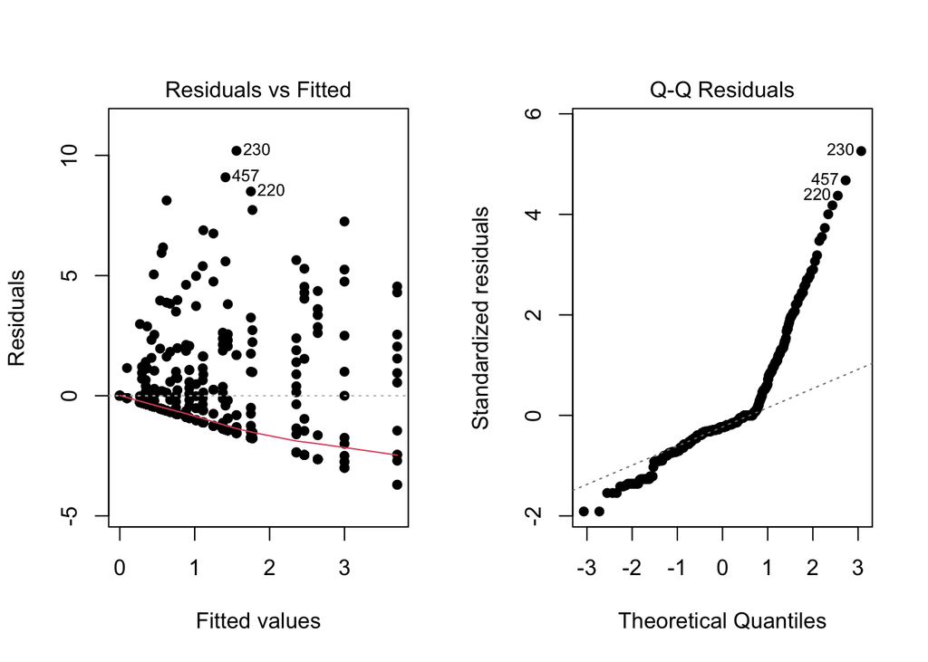

```r
par(mfrow=c(1,2))
plot(hours_aov, which=1:2, pch=16)
```

### Graphics and Numerical Summaries

The three following graphics with accompanying numerical summaries visualize the test results against each set of hypotheses.

**Disclaimer:** These results should be interpreted with caution.

#### Weekday

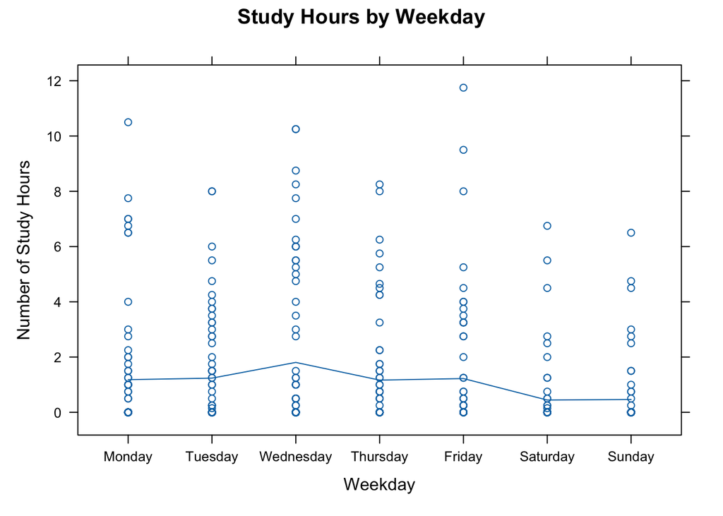

```r
# ————————————————————————————————————————————————————————————————————————
# NOTE 1:

# Originally I created this plot but it wasn't tracing the means across the continuous axis (Weekday).
# I wanted this because it would reveal study habits across the course of the week.
# So, ChatGPT gave me the commented out code for a plot which adds the line as I desired.
# It also adds a few other styling elements such as marking the mean with a filled marker and thickening the line.

# NOTE 2:

# However, I figured out I needed to update my data cleaning up above to remove records with null values in the "Hours" column.
# This solved the problem.
# ————————————————————————————————————————————————————————————————————————

# Code source: author
xyplot(Hours ~ Weekday,
       data = StudyHours,
       type = c("p", "a"), # points and averages
       main = "Study Hours by Weekday",
       xlab = "Weekday",
       ylab = "Number of Study Hours")
```

```r
# Code Source: ChatGPT (didn't end up)
# xyplot(Hours ~ Weekday, data = StudyHours,
#        main = "Study Hours by Weekday",
#        xlab = "Weekday", ylab = "Number of Study Hours",
#        panel = function(x, y, ...) {
#          # points
#          panel.stripplot(x, y, jitter.data = TRUE, factor = 0.6, pch = 1, ...)
#          # means
#          means <- tapply(y, x, mean, na.rm = TRUE)
#          panel.lines(seq_along(means), means, lwd = 2)
#          panel.points(seq_along(means), means, pch = 16, cex = 1.1)
#        })
```

This dot plot shows a clear variation in study hours across days of the week, with the highest concentration of study time occurring midweek, particularly on Wednesdays. Fewer hours were logged on weekends, especially Saturday. The smooth line trend suggests a midweek peak followed by a weekend drop.

```r
# Disclosure: ChatGPT helped me learn how to include a standard deviation value that has three digits after the decimal in a compatible manner with pander().

favstats(Hours ~ Weekday, data = StudyHours) %>%
  select(Weekday, mean, sd) %>%
  mutate(
    Mean = mean,
    SD = sprintf("%.3f", sd) # <------- Source: ChatGPT
  ) %>%
  select(Weekday, Mean, SD) %>%
  pander(
    justify = c("left", "center", "center"),
    caption = "Mean and SD of Study Hours by Weekday"
  )
```

Mean and SD of Study Hours by Weekday

| Weekday | Mean | SD |
| --- | --- | --- |
| Monday | 1.182 | 2.295 |
| Tuesday | 1.238 | 1.953 |
| Wednesday | 1.807 | 2.882 |
| Thursday | 1.166 | 2.040 |
| Friday | 1.223 | 2.387 |
| Saturday | 0.4446 | 1.283 |
| Sunday | 0.4654 | 1.255 |

Wednesday had both the highest mean (1.807 hrs) and the highest standard deviation (2.882), indicating it was not only the most studied day but also showed wide variation in study duration by the Student. In contrast, Saturday had the lowest mean (0.4446 hrs) and a low standard deviation (1.283), suggesting more consistently low study hours. The standard deviations reflect how the Student’s weekday study behavior varied more from week to week than it did on weekends.

#### Course

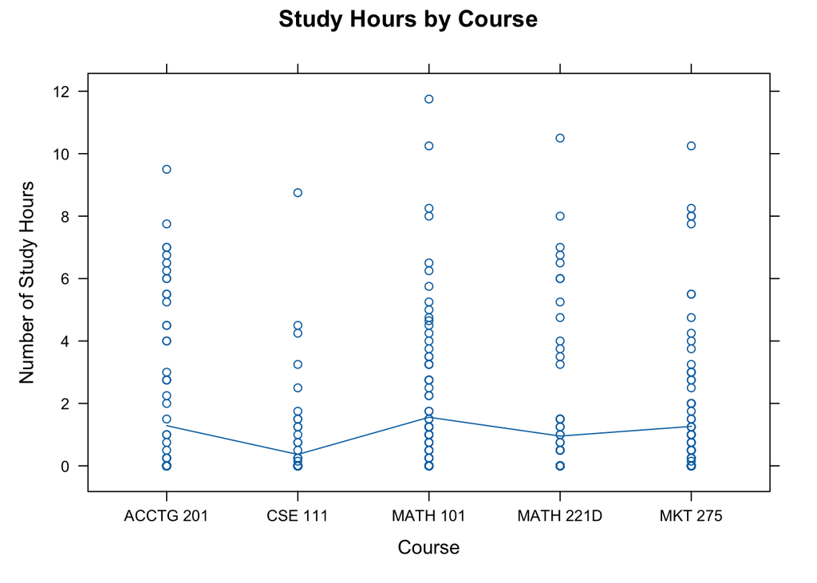

```r
xyplot(Hours ~ as.factor(Course_Code),
       data = StudyHours,
       type = c("p", "a"), # points and averages
       main = "Study Hours by Course",
       xlab = "Course",
       ylab = "Number of Study Hours"
      )
```

The plot displays individual study time per course, with MATH 101 and ACCTG 201 having the highest visible clusters of study hours. CSE 111 consistently shows the lowest study hour values with minimal spread.

```r
# Disclosure: ChatGPT helped me learn how to include a standard deviation value that has three digits after the decimal in a compatible manner with pander().

favstats(Hours ~ Course_Code, data = StudyHours) %>%
  select(Course_Code, mean, sd) %>%
  mutate(
    Mean = sprintf("%.3f", mean),
    SD = sprintf("%.3f", sd) # <------- Source: ChatGPT
  ) %>%
  select(Course_Code, Mean, SD) %>%
  pander(
    justify = c("left", "center", "center"),
    caption = "Mean and SD of Study Hours by Course"
  )
```

Mean and SD of Study Hours by Course

| Course_Code | Mean | SD |
| --- | --- | --- |
| ACCTG 201 | 1.288 | 2.363 |
| CSE 111 | 0.366 | 1.193 |
| MATH 101 | 1.557 | 2.425 |
| MATH 221D | 0.955 | 2.117 |
| MKT 275 | 1.265 | 2.171 |

MATH 101 had the highest mean study time (1.557 hrs), followed by ACCTG 201 (1.288 hrs), suggesting those courses required or received more attention. CSE 111 had the lowest mean (0.366 hrs) and the smallest standard deviation (1.193), suggesting less time spent and more consistency in study habits. Larger standard deviations for MATH 101 and ACCTG 201 (2.425 and 2.363, respectively) indicate broader variability in how the Student approached those courses.

#### Course:Weekday

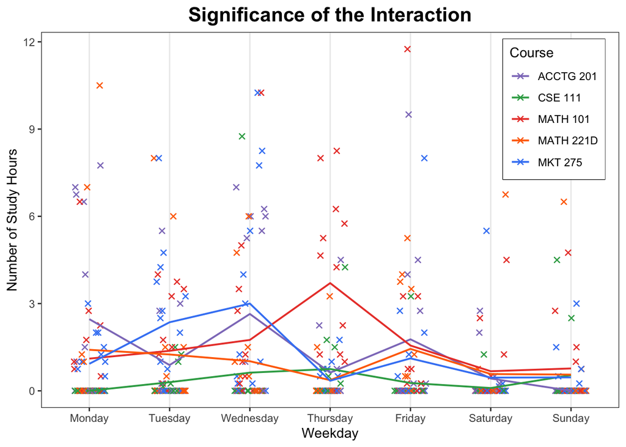

```r
# ————————————————————————————————————————————————————————————————————————
# DISCLOSURE:

# I wrote the majority of the code below but did not know how to use a reference dataframe to build a color palette and insert it into the plot code to color the secondary geometry ("line").
# ChatGPT aided me by showing me how to first define the color pallet and then where to insert it into the plot's code.
# ————————————————————————————————————————————————————————————————————————

# ATTEMPT 1: (source: Author)

# xyplot(Hours ~ as.factor(Weekday),
#        data = StudyHours,
#        group = as.factor(Course_Code),    # sets legend groups
#        type = c("p", "a"),                # points and averages
#        auto.key = TRUE,                   # automatically generates legend
#        main = "Study Hours by Weekday and Course",
#        xlab = "Weekday",
#        ylab = "Number of Study Hours")



# ATTEMPT 2: (source: Author)

# ggplot(StudyHours, aes(x=Weekday, y=Hours, group=Course_Code, color = Course_Code)) +
#   geom_point(color = "skyblue") +
#   scale_fill_manual(aes(Color_Guide, color = Hex_Code)) +
#   stat_summary(fun="mean", geom="line") +
#   labs(
#     title="Placeholder",
#     x="Weekday (colored by Course)",
#     y="Number of Study Hours"
#   ) +
#   theme_bw()



# ATTEMPT 3: (source: ChatGPT (modifying Author's code))
# Additions: ChatGPT showed me how to add a jitter effect to the point geometry.

# palette: "course code" → "#hex"
pal <- with(Color_Guide, setNames(Hex_Code, Course_Code))

ggplot(StudyHours, aes(Weekday, Hours, group = Course_Code, color = Course_Code)) +
  geom_jitter(width = 0.2, height = 0, pch = 4, stroke = .7) +
  stat_summary(fun = "mean", geom = "line", linewidth = 0.7) +
  scale_color_manual(values = pal, name = "Course") +
  labs(
    title = "Significance of the Interaction",
    x = "Weekday",
    y = "Number of Study Hours"
  ) +
  theme_bw() +
  theme(
    legend.position = c("top", "right"),
    legend.justification = c(.97,.97),
    legend.box.background = element_rect(color = "black"),
    # legend.background = element_text(color = "black"),
    plot.title = element_text(face="bold", hjust = .5, size = 16),
    panel.grid.major.y = element_blank(),
    panel.grid.minor.y = element_blank()
  )
```

The interaction plot indicates *varying* patterns for each course across the week. Notably, MKT 275 spikes on Wednesday and ACCTG 201 is higher on Monday and Wednesday. These patterns suggest that study habits are not consistent across courses and are influenced by the day of the week.

```r
# ————————————————————————————————————————————————————————————————————————
# DISCLOSURE:

# I wrote the commented out code however I am still learning how to pivot data so I relied on ChatGPT to modify my code to accomplish this so the data was wide not long thus greatly simplifying the viewing experience and data intake for the reader.
# ————————————————————————————————————————————————————————————————————————

# Source: Author
# numSummary <- StudyHours %>%
#   group_by(Weekday, Course_Code) %>%
#   summarise(
#     `Mean Study Hours` = round(mean(Hours, na.rm = TRUE), 2),
#     .groups = "drop"
#   )
#
# pander(numSummary)


# Code Source: ChatGPT (modifying Author's code)

## Mean table
meanSummary_wide <- StudyHours %>%
  group_by(Course_Code, Weekday) %>%
  summarise(`Mean Study Hours` = sprintf("%.2f", mean(Hours, na.rm = TRUE)), .groups = "drop") %>%
  pivot_wider(names_from = Weekday, values_from = `Mean Study Hours`)

pander(meanSummary_wide,
       justify = c("left", rep("right", 7)),
       caption = "Mean of Study Hours by Course and Weekday (formatted to 2 decimal places)")
```

Mean of Study Hours by Course and Weekday (formatted to 2 decimal places)

| Course_Code | Monday | Tuesday | Wednesday | Thursday | Friday | Saturday | Sunday |
| --- | --- | --- | --- | --- | --- | --- | --- |
| ACCTG 201 | 2.46 | 0.88 | 2.64 | 0.62 | 1.77 | 0.42 | 0.00 |
| CSE 111 | 0.00 | 0.30 | 0.62 | 0.75 | 0.27 | 0.10 | 0.54 |
| MATH 101 | 1.11 | 1.38 | 1.75 | 3.70 | 1.56 | 0.67 | 0.77 |
| MATH 221D | 1.41 | 1.25 | 1.02 | 0.37 | 1.44 | 0.58 | 0.56 |
| MKT 275 | 0.93 | 2.36 | 3.00 | 0.35 | 1.12 | 0.45 | 0.46 |

Study hours vary greatly between courses on specific days. For example, MKT 275 peaks on Wednesday (3.00 hrs), while CSE 111 is consistently low across the board. This supports the presence of an interaction effect where both course and weekday jointly influence study hours.

```r
## SD table
sdSummary_wide <- StudyHours %>%
  group_by(Course_Code, Weekday) %>%
  summarise(`SD Study Hours` = sprintf("%.2f", sd(Hours, na.rm = TRUE)), .groups = "drop") %>%
  pivot_wider(names_from = Weekday, values_from = `SD Study Hours`)

pander(sdSummary_wide,
       justify = c("left", rep("right", 7)),
       caption = "SD of Study Hours by Course and Weekday (formatted to 2 decimal places)")
```

SD of Study Hours by Course and Weekday (formatted to 2 decimal places)

| Course_Code | Monday | Tuesday | Wednesday | Thursday | Friday | Saturday | Sunday |
| --- | --- | --- | --- | --- | --- | --- | --- |
| ACCTG 201 | 3.18 | 1.75 | 3.05 | 1.39 | 2.96 | 0.89 | 0.00 |
| CSE 111 | 0.00 | 0.53 | 2.34 | 1.21 | 0.90 | 0.35 | 1.38 |
| MATH 101 | 1.81 | 1.60 | 2.91 | 2.92 | 3.28 | 1.37 | 1.46 |
| MATH 221D | 3.21 | 2.52 | 1.92 | 0.96 | 1.93 | 1.87 | 1.80 |
| MKT 275 | 0.94 | 2.33 | 3.57 | 0.55 | 2.26 | 1.52 | 0.88 |

### Conclusion

The interaction plot and accompanying summaries demonstrate that both the day of the week and the course influence study behavior, confirming the presence of an interaction effect. Courses like MKT 275 and ACCTG 201 show sharp peaks on specific days (e.g., Wednesday and Monday), while CSE 111 remains consistently low across the week. The inclusion of standard deviations further emphasizes that some courses exhibit highly variable study patterns (e.g., MATH 101), whereas others show steady routines. These findings support the conclusion that study habits are not uniform and are shaped by the combined influence of course demands and scheduling tendencies throughout the week.

Despite violations of normality and homoscedasticity assumptions, the ANOVA results suggest significant effects for:

- Weekday (p = 0.001142)
- Course (p = 0.0008493)
- Weekday × Course Interaction (p = 0.006241)

This means the data provides evidence that study hours differ not only by day of the week and by course but also that the effect of weekday depends on the course—some courses are studied more on specific days than others.

However, due to non-normal residuals and unequal variances, these results should be interpreted with caution. A non-parametric or transformation-based approach may offer more robust conclusions in future analyses.